# Lab 1B

Bias-variance trade-off

Mahdi Shafiee Kamalabad and Maarten Cruyff

2026

# Getting Started: Loading the Dataset

Before you begin the practical, you need to load the required dataset into R. To ensure a smooth workflow, please follow one of the two options below:

**Option 1: Using a Dedicated Folder**

Create a specific folder for this assignment and place the dataset file inside it. You can then load the data using the `load()` function by specifying the correct file path. (Note for Windows users: Please ensure you change all backslashes `\` in your copied file path to forward slashes `/` in R).

For **Mac** users, your path will look like this:

```r
load("/Users/your_username/Documents/folder_name/dataset_name.RData")
```

For **Windows** users, your path will look like this:

```r
load("C:/Users/your_username/Documents/folder_name/dataset_name.RData")
```

**Option 2: Using an R Project**

Create an R Project (`.Rproj`) for this assignment and store the dataset directly within that project folder. Make sure to open RStudio by double-clicking the `.Rproj` file. This automatically sets your working directory, allowing you to load the dataset directly without a long path:

```r
load("dataset_name.RData")
```

**Note for this specific lab:** While the above options outline the standard workflow for local files, you do not need to download or load a `.RData` file for this specific lab. Today, we will access our data directly through an R package.

# Lab overview

## The data

We use the **`Auto`** dataset from the **`ISLR`** package, which contains characteristics of automobiles from the 1970s and early 1980s.

In this lab, we focus on two variables: - **`mpg`**: miles per gallon (fuel efficiency)  
- **`displacement`**: engine displacement

## The task

The goal of this lab is to predict **`mpg`** from **`displacement`** and compare models of increasing complexity/flexibility: - **Linear regression** - **Quadratic regression** - **$k$-nearest neighbors (KNN)**

Model selection is performed using the **train / validation (dev) / test paradigm**.

## Lab structure

1. **Partition and visualize the data**
2. **Train the models**
3. **Evaluate and compare the models on a test set**

# Partition and visualize the data

1. Load required packages

   Before you start, load the following packages:

   **Hint:** Use the `library()` function to load the required packages.

**Show Answer**

```r
library(ggplot2)
library(caret)
library(ISLR)
library(dplyr)
```

Note: If you already have the `tidyverse` package installed and loaded, you do not need to load ggplot2 and dplyr separately, as they are included in tidyverse.

2. Partitioning the data means splitting it into **training** and **test** sets so that model performance can be evaluated fairly.

   **Hint:** Use `set.seed(1)` and the `sample()` function to generate indices for 80% of the rows.

**Show Answer**

```r
set.seed(1)

train_idx <- sample(nrow(Auto), size = 0.8 * nrow(Auto))

Auto_train <- Auto[train_idx, ]
Auto_test  <- Auto[-train_idx, ]
```

3. Display a scatter plot with `displacement` on the x-axis and `mpg` on the y-axis. Display the cases in the training set in blue, and the cases in the test set in red.

   **Hint:** Use `ggplot()` with two `geom_point()` layers, specifying `data = Auto_train` for one and `data = Auto_test` for the other.

**Show Answer**

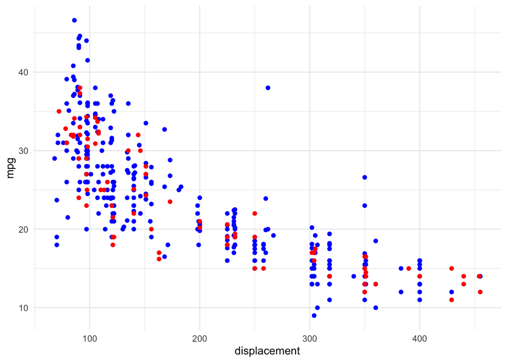

```r
ggplot() +
  geom_point(data = Auto_train,  aes(displacement, mpg), col = "blue") +
  geom_point(data = Auto_test, aes(displacement, mpg), col = "red") +
  theme_minimal()
```

# Training the models

## Linear regression model

In this model: - **Outcome variable (Y):** `mpg`  
- **Predictor (X):** `displacement`

The linear regression model to be fitted is

$$\widehat{mpg} = \beta_0 + \beta_1 \cdot
\text{displacement}$$

This model assumes a **linear relationship** between engine displacement and fuel efficiency. The linear regression model is fitted in R using the function `lm()`.  
If you are unfamiliar with this function, consult its help page (e.g., type `?lm` in the R console) before proceeding.

1. Fit the linear regression model to the **training set** and save the fitted model under the name `linear`.

   **Hint:** The function `lm()` has the form `lm(formula, data)` where `formula` specifies the outcome and predictor variables.

**Show Answer**

```r
linear <- lm(mpg ~ displacement, data = Auto_train)
```

2. Display and interpret the summary of the fitted linear regression model.

   **Hint:** The function `summary()` provides information about the estimated coefficients, their statistical significance, and overall model fit.

**Show Answer**

```r
summary(linear)
```

```
##
## Call:
## lm(formula = mpg ~ displacement, data = Auto_train)
##
## Residuals:
##      Min       1Q   Median       3Q      Max
## -13.1999  -3.0339  -0.7054   2.2857  18.7190
##
## Coefficients:
##               Estimate Std. Error t value Pr(>|t|)
## (Intercept)  35.545281   0.578811   61.41   <2e-16 ***
## displacement -0.062078   0.002663  -23.31   <2e-16 ***
## ---
## Signif. codes:  0 '***' 0.001 '**' 0.01 '*' 0.05 '.' 0.1 ' ' 1
##
## Residual standard error: 4.763 on 311 degrees of freedom
## Multiple R-squared:  0.636,  Adjusted R-squared:  0.6348
## F-statistic: 543.4 on 1 and 311 DF,  p-value: < 2.2e-16
```

3. Compute the **training Mean Squared Error (MSE)** for the linear regression model and display its value.

   The MSE measures the **average squared difference** between the observed values and the model predictions.

   **Hint:** Use the fitted model object `linear` and extract the residuals using the function `resid()`.

**Show Answer**

```r
mean(resid(linear)^2)
```

```
## [1] 22.5429
```

## Quadratic regression model

The quadratic regression model to be fitted is

$$\widehat{mpg}=\beta_0+\beta_1\cdot{displacement}+\beta_2\cdot{displacement}^2$$

The square of `displacement` can be included in the model formula with `I(displacement^2)` (the `I()` function literally performs the specified operation).

1. Fit the quadratic regression model to the training data, and save the object as `quadratic`.

   **Hint:** Include `I(displacement^2)` in your formula inside the `lm()` function.

**Show Answer**

```r
quadratic <- lm(mpg ~ displacement + I(displacement^2), data = Auto_train)
```

2. Display and interpret the summary of this model.

   **Hint:** Use the `summary()` function on your `quadratic` object.

**Show Answer**

```r
summary(quadratic)
```

```
##
## Call:
## lm(formula = mpg ~ displacement + I(displacement^2), data = Auto_train)
##
## Residuals:
##      Min       1Q   Median       3Q      Max
## -15.3759  -2.3776  -0.4853   2.1725  20.4052
##
## Coefficients:
##                     Estimate Std. Error t value Pr(>|t|)
## (Intercept)        4.221e+01  1.307e+00  32.288  < 2e-16 ***
## displacement      -1.380e-01  1.373e-02 -10.050  < 2e-16 ***
## I(displacement^2)  1.682e-04  2.989e-05   5.627  4.1e-08 ***
## ---
## Signif. codes:  0 '***' 0.001 '**' 0.01 '*' 0.05 '.' 0.1 ' ' 1
##
## Residual standard error: 4.544 on 310 degrees of freedom
## Multiple R-squared:  0.6697, Adjusted R-squared:  0.6676
## F-statistic: 314.3 on 2 and 310 DF,  p-value: < 2.2e-16
```

3. Compute the training MSE for this model, and compare it to the training MSE of the linear model. Which model performs best on the training set? Briefly explain **why** this result is expected.

   **Hint:** Use `mean(resid(quadratic)^2)` and think about how adding polynomial terms affects training error.

**Show Answer**

```r
mean(resid(quadratic)^2)
```

```
## [1] 20.4538
```

## $k$-nearest neighbors (KNN)

The KNN model is a **nonparametric** method with a key hyperparameter:  
the number of nearest neighbors, $k$.

The choice of $k$ controls model flexibility: - small $k$ → more flexible model  
- large $k$ → smoother model

Because of this, **cross-validation is required** to select an appropriate value of $k$.

The R code for training a KNN model using **5-fold cross-validation** is provided in the lecture slides.

1. Perform a 5-fold cross validation on the training set for $k\in\{ 1, 2, 5, 10, 25, 50, 100\}$ using the function `train()`. Save the fitted model object under the name `knn`.

   **Hint:** In the `caret` package, KNN is trained with `method = "knn"`. You can specify the values of $k$ using `tuneGrid`, and control cross-validation using `trainControl()`.

**Show Answer**

```r
knn <- train(mpg ~ displacement,
             data = Auto_train,
             method = "knn",
             tuneGrid = expand.grid(k = c(1, 2, 5, 10, 25, 50, 100)),
             trControl = trainControl(method = "cv", number = 5))
```

2. Display and interpret the contents of the object `knn`. Which value of $k$ yields the **lowest RMSE**? (Remember that RMSE is the square root of the MSE). Briefly explain how cross-validation is used here to select $k$.

   **Hint:** Simply type `knn` to view the results and look for the row with the lowest RMSE.

**Show Answer**

```r
knn
```

```
## k-Nearest Neighbors
##
## 313 samples
##   1 predictor
##
## No pre-processing
## Resampling: Cross-Validated (5 fold)
## Summary of sample sizes: 252, 250, 251, 250, 249
## Resampling results across tuning parameters:
##
##   k    RMSE      Rsquared   MAE
##     1  4.807981  0.6551599  3.522589
##     2  4.691465  0.6700786  3.500333
##     5  4.415542  0.6938562  3.347389
##    10  4.366952  0.6989671  3.298348
##    25  4.305888  0.7033896  3.241467
##    50  4.375366  0.6944171  3.301234
##   100  4.666888  0.6648852  3.575024
##
## RMSE was used to select the optimal model using the smallest value.
## The final value used for the model was k = 25.
```

3. Compute the **training MSE** for the KNN model and compare it to the training MSEs of the **linear** and **quadratic** regression models. Which model performs best on the training set? Briefly explain **why** this result is expected.

   **Hint:** Extract the RMSE from `knn$results`, square it, and compare it to the previously calculated MSEs.

**Show Answer**

```r
min(knn$results$RMSE^2)
```

```
## [1] 18.54067
```

## Visualizing the predictions

1. To visualize and compare the fitted models, create a data frame `Train` that contains the **training data** along with the **predicted values** from each model. This allows us to directly compare how the linear, quadratic, and KNN models fit the training data.

   **Hint:** You may find the function `mutate()` from the `dplyr` package useful for adding predicted values as new columns.

**Show Answer**

```r
Train <- mutate(Auto_train,
                pred_linear    = predict(linear),
                pred_quadratic = predict(quadratic),
                pred_knn       = predict(knn))
```

2. Display a **scatterplot of the training data** and add the fitted curves from the three models:
- linear regression
- quadratic regression
- KNN

  Use `geom_line()` to overlay the fitted values for each model, and give each line a **different color**.

  **Hint:** Make sure the predicted values are plotted against `displacement`.

**Show Answer**

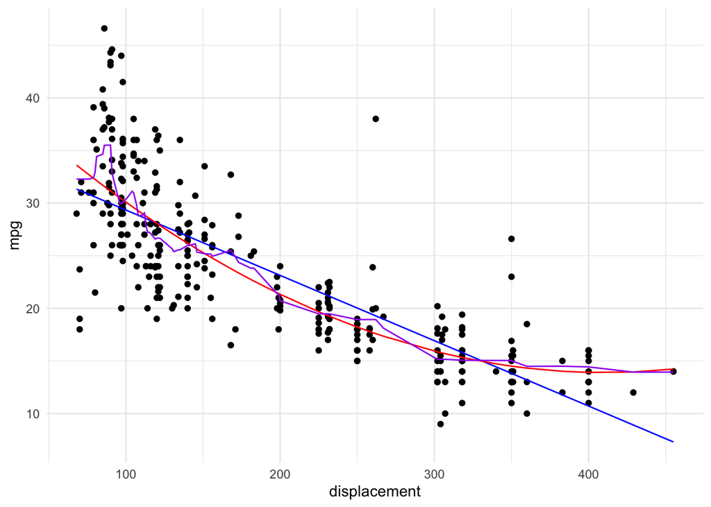

```r
ggplot(Train) +
  geom_point(aes(displacement, mpg)) +
  geom_line(aes(x = displacement, y = pred_linear), col = "blue") +
  geom_line(aes(x = displacement, y = pred_quadratic), col = "red") +
  geom_line(aes(x = displacement, y = pred_knn), col = "purple") +
  theme_minimal()
```

# Testing the models

To evaluate how well the models **generalize to new data**, obtain predictions for the **test set** and compute the **MSE** for each model.

The test set was **not used during model training or selection**, so the test MSE provides an unbiased estimate of **out-of-sample** performance.

1. Create a data frame `Test` that contains the **test data** along with the **predicted values** from each of the fitted models.

   These predictions will be used to compute the **test MSE** and compare model performance on new, unseen data.

   **Hint:** You can use `mutate()` to add predicted values as new columns, and `predict()` to obtain predictions from each model on the `Auto_test` dataset.

**Show Answer**

```r
Test <- mutate(Auto_test,
                pred_linear    = predict(linear, Auto_test),
                pred_quadratic = predict(quadratic, Auto_test),
                pred_knn       = predict(knn, Auto_test))
```

2. Compute and display the **MSE** for the three models:
- linear regression
- quadratic regression
- KNN

  Which model performs best on the **test set**?  
  What do you conclude about the other two models — are they **underfitting** or **overfitting** the data?

  **Hint:** The test MSE measures how well a model generalizes to new data. Calculate the mean squared difference between `mpg` and each prediction column.

**Show Answer**

```r
Test %>% summarise(testMSE_linear    = mean((mpg - pred_linear)^2),
                   testMSE_quadratic = mean((mpg - pred_quadratic)^2),
                   testMSE_knn       = mean((mpg - pred_knn)^2))
```

```
##   testMSE_linear testMSE_quadratic testMSE_knn
## 1       16.97269          12.87248    13.27637
```

3. Plot the **test data** and overlay the predictions from the three models:
- linear regression
- quadratic regression
- KNN

  Use different colors to distinguish the fitted curves. This visualization helps assess how well each model **generalizes** to new data.

  **Hint:** Use `ggplot()` with `Test` data, mapping `displacement` and `mpg` to points, and the prediction columns to `geom_line()` with different colors.

**Show Answer**

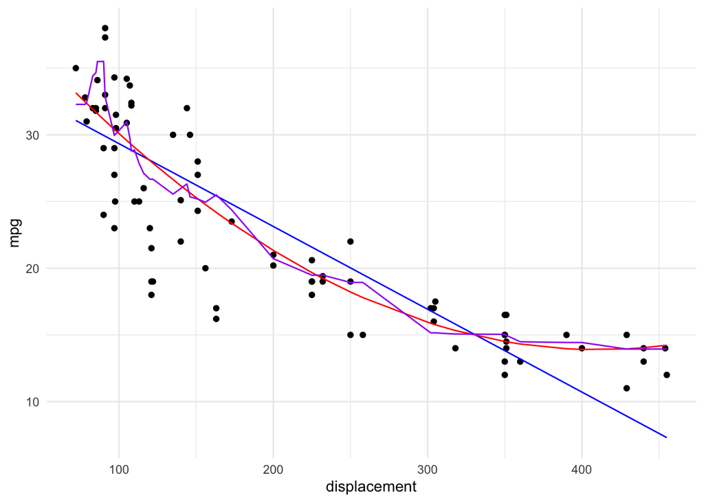

```r
ggplot(Test) +
  geom_point(aes(displacement, mpg)) +
  geom_line(aes(x = displacement, y = pred_linear), col = "blue") +
  geom_line(aes(x = displacement, y = pred_quadratic), col = "red") +
  geom_line(aes(x = displacement, y = pred_knn), col = "purple") +
  theme_minimal()
```

4. (Optional) Advanced exercise: Tuning model flexibility

   This exercise is intended for students who want to explore model flexibility in more detail. Sensitivity of KNN to the choice of $k$

   In the KNN model, the value of $k$ controls how flexible the model is.
   1. Using the results stored in the object `knn`, create a plot showing the **cross-validated RMSE as a function of $k$**.
   2. Explain how the choice of $k$ affects model bias and variance.
   3. What happens when $k$ is very small? What happens when $k$ is very large?

   **Hint:** The cross-validation results are stored in the `results` component of the `knn` object. You can pass `knn$results` directly into `ggplot()`.

**Show Answer**

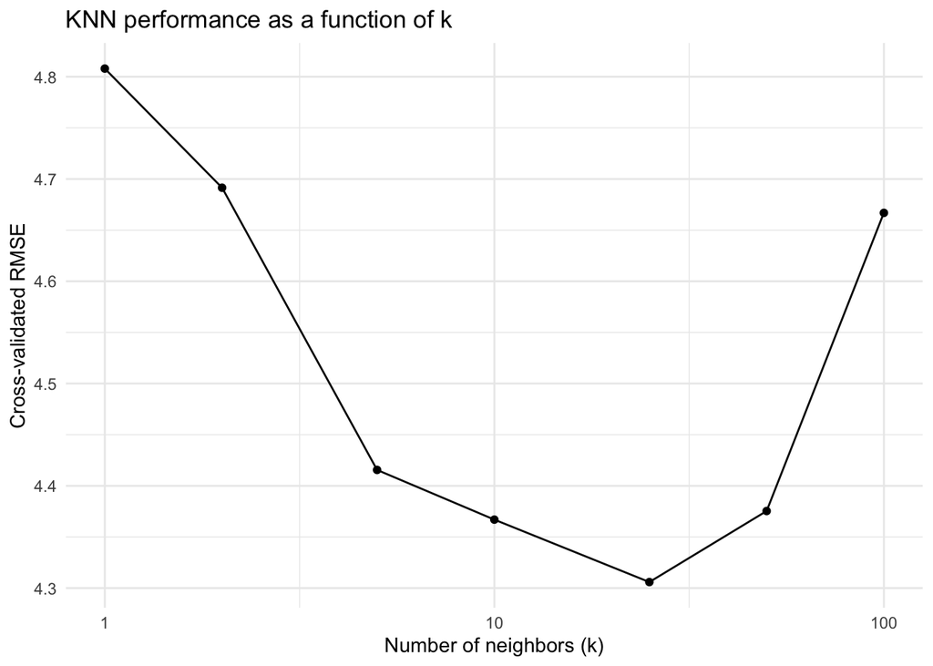

```r
ggplot(knn$results, aes(x = k, y = RMSE)) +
  geom_point() +
  geom_line() +
  scale_x_continuous(trans = "log10") +
  theme_minimal() +
  labs(
    x = "Number of neighbors (k)",
    y = "Cross-validated RMSE",
    title = "KNN performance as a function of k"
  )
```

END OF LAB